# Proliferation assay

Simulate the proliferation assay of Q’s group with our model

Authors

Nicholas Harbour

Markus Owen

Published

August 05, 2024, 14:39:34

Modified

August 05, 2024, 14:39:13

# 1 import packages and define functions

```python
import numpy as np
import matplotlib.pyplot as plt
import pandas as pd
import scipy.stats as stats
from scipy.stats import lognorm
from numba import jit
import matplotlib.colors as mcolors
import seaborn as sns
```

all functions are in: “notebooks/gsc_model_functions.py”

```python
import gsc_model_functions as gmf
```

For this we need to load in the patient data and calculate the distribution params

```python
# load in the patient survival data
historic_df = pd.read_csv("Data/Rho_D_data.csv")
censored_str = "Censorship (1=censored)"
survival_str = "Overall Survival"
# only keep patients that weren't censored
historic_df = historic_df[historic_df[censored_str] == 0]
# cut off patients that had very high proliferation rate
historic_df = historic_df[historic_df["PIHNA rho"] < 100 ]
historic_df[censored_str] = True

# fit distribution to the data
dist_name = 'lognorm'  # Replace with the desired distribution name
dist = getattr(stats, dist_name)
params = dist.fit(historic_df["PIHNA rho"])

shape = params[0]
loc = params[1]
scale = params[-1]
```

The experimental protocol: after cell seeding, cells were treated for a brief period for 7 days with BMP4. At day 7, the plate was centrifuged, and the media was removed, and the cell pellet was collected and frozen. The following day, the pellet was resuspended with the lysis buffer (kit method, [cyquant assay](https://www.thermofisher.com/order/catalog/product/C7026)) and the plate was read at 528nm.

Fluorescence at DO528nm is due to the presence of fluorescent dye SYBR green. Query this as I’d expect it to be due to CyQuant GR.

This assay determines the number of cells. Original reference is Sensitive determination of cell number using the CyQUANT cell proliferation assay, Jones et al, 2001

# 2 Load proliferation data

```python
prolif_df1 = pd.read_csv("Data/BMP4 and Proliferation data-1.csv")
prolif_df2 = pd.read_csv("Data/BMP4 and Proliferation data-2.csv")
prolif_df3 = pd.read_csv("Data/BMP4 and Proliferation data-3.csv")
```

## 2.1 remove data with exclude=yes

```python
prolif_df2 = prolif_df2[prolif_df2.exclude!="yes"]
```

# 3 Exploratory plots

## 3.1 Boxplot the raw data for each cell line

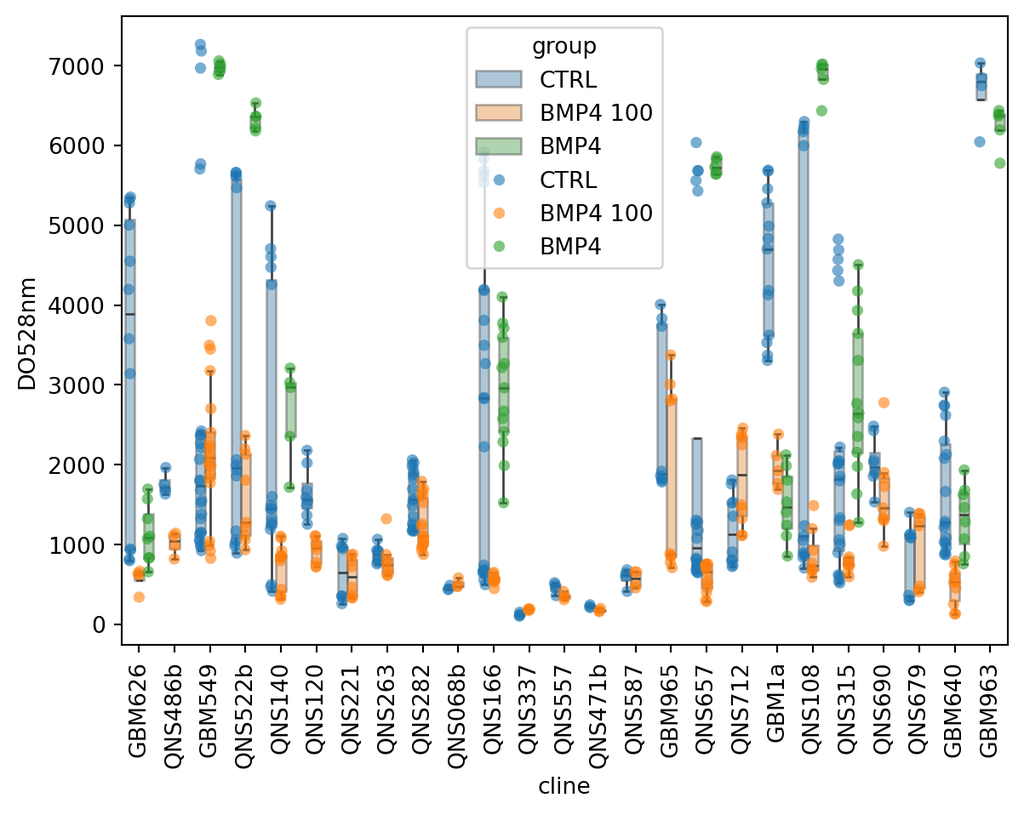

```python
plt.figure()
plt.xticks(rotation='vertical')
sns.boxplot(data=prolif_df2, x='cline', y='DO528nm', hue='group', showfliers=False, boxprops={'alpha': 0.4})
sns.stripplot(data=prolif_df2, x='cline', y='DO528nm', hue='group', dodge=True, alpha=0.6)
```

## 3.2 Plot the cell proliferation data for GBM1a only

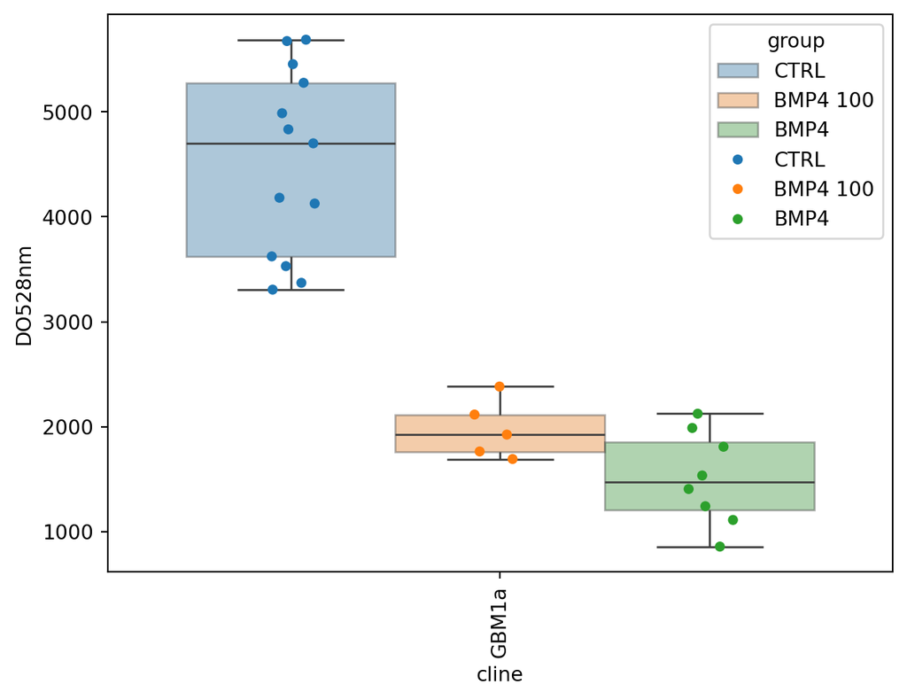

```python
plt.figure()
plt.xticks(rotation='vertical')
sns.boxplot(data=prolif_df2[prolif_df2.cline=="GBM1a"], x='cline', y='DO528nm', hue='group', showfliers=False, boxprops={'alpha': 0.4})
sns.stripplot(data=prolif_df2[prolif_df2.cline=="GBM1a"], x='cline', y='DO528nm', hue='group', dodge=True)
```

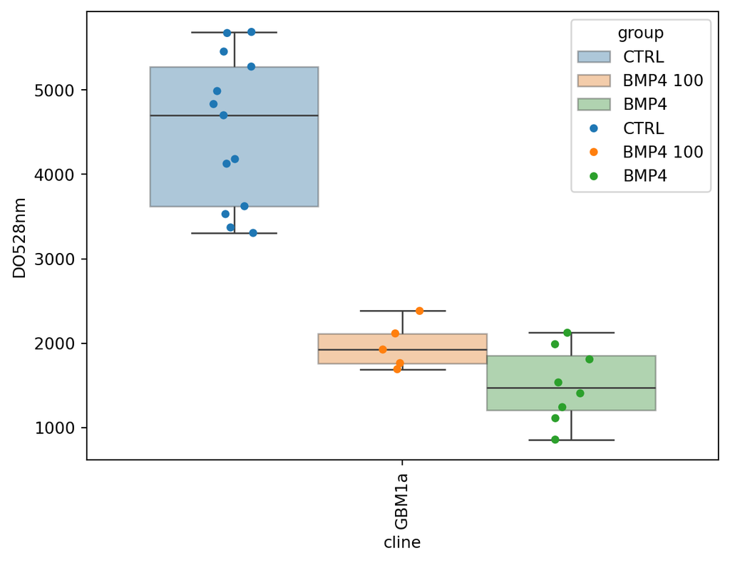

```python
plt.figure()
plt.xticks(rotation='vertical')
sns.boxplot(data=prolif_df2[(prolif_df2.cline=="GBM1a") & (prolif_df2.exclude!="yes")], x='cline', y='DO528nm', hue='group', boxprops={'alpha': 0.4})
sns.stripplot(data=prolif_df2[(prolif_df2.cline=="GBM1a") & (prolif_df2.exclude!="yes")], x='cline', y='DO528nm', hue='group', dodge=True)
```

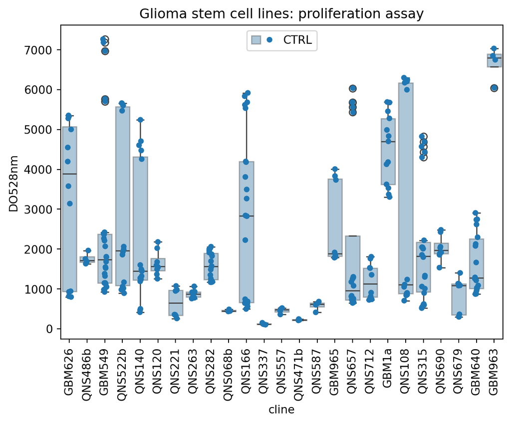

```python
from matplotlib.legend_handler import HandlerTuple

plt.figure()
plt.xticks(rotation='vertical')
ax = sns.boxplot(data=prolif_df2[(prolif_df2.group=="CTRL") & (prolif_df2.exclude!="yes")], x='cline', y='DO528nm', hue='group', boxprops={'alpha': 0.4})
sns.stripplot(data=prolif_df2[(prolif_df2.group=="CTRL") & (prolif_df2.exclude!="yes")], x='cline', y='DO528nm', hue='group', dodge=True, ax=ax)
handles, labels = ax.get_legend_handles_labels()
ax.legend(handles=[(handles[0], handles[1])],
          labels=['CTRL'],
          loc='upper center', handlelength=2,
          handler_map={tuple: HandlerTuple(ndivide=None)})
ax.set_title("Glioma stem cell lines: proliferation assay")
```

```python
### import params
from gsc_model_params import n,delta_s,delta_v,k,psi,Ps_max,Ps_min,mv_rho_scale,ms_mv_scale

### override some parameters ###

# constants
s0 = 0.1 # IC of GSCs

# range of BMP4 doses
BMP4_doses = [0,1,10,100]

# set up time grid
dt = 0.01
t_final = 7
t = np.arange(0, t_final+dt/2, dt)
nt = len(t)

# use the mean of the fitted distribution to give proliferation rate
pro_rate = loc+scale*np.exp(shape**2/2)
mv = mv_rho_scale*pro_rate*np.ones(n)
ms = ms_mv_scale*mv[0]
mv[n-1] = 0

# calc alpha as proportional to rho
alpha = gmf.calc_alpha_from_rho(mv[0])
beta = gmf.calc_beta(alpha)

N_save = np.zeros((len(BMP4_doses),len(t)))

for j in range(len(BMP4_doses)):


    Ps = Ps_min + (Ps_max - Ps_min)*(1 / (1 + psi*BMP4_doses[j]))

    u = np.zeros((nt,n+1))
    VS = np.zeros(nt)
    N = np.zeros(nt)

    # define IC
    u[0,0] = s0
    VS[0] = np.sum(u[0,1:n+1]) # sum the 1th to nth entries
    N[0] = u[0,0] + VS[0]
    N_save[j,0] = N[0]

    i = 0
    while t[i] < t_final:
            u[i+1,:] = u[i,:] + dt * gmf.gsc_model_dudt(u[i,:],n,Ps,k,ms,mv,delta_s,delta_v)

            VS[i+1] = np.sum(u[i+1,1:n+1])
            N[i+1] = u[i+1,0] + VS[i+1]

            i = i +1



    N_save[j,:] = N # for each BMP4 dose save the time course of total population
```

Plot total tumour size over the course of proliferation assay

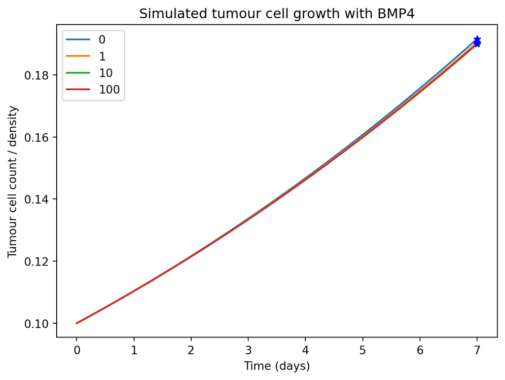

```python
colors = list(mcolors.TABLEAU_COLORS)
for j in range(len(BMP4_doses)):
    plt.plot(t,N_save[j,:],c = colors[j],label = BMP4_doses[j])
    plt.plot(t[-1],N_save[j,-1],'b*')

plt.xlabel("Time (days)")
plt.ylabel("Tumour cell count / density")
plt.legend()
plt.title("Simulated tumour cell growth with BMP4")

plt.show()
```

Plot the final result of the assay (tumour cell population after 7 days for different BMP4 doses)

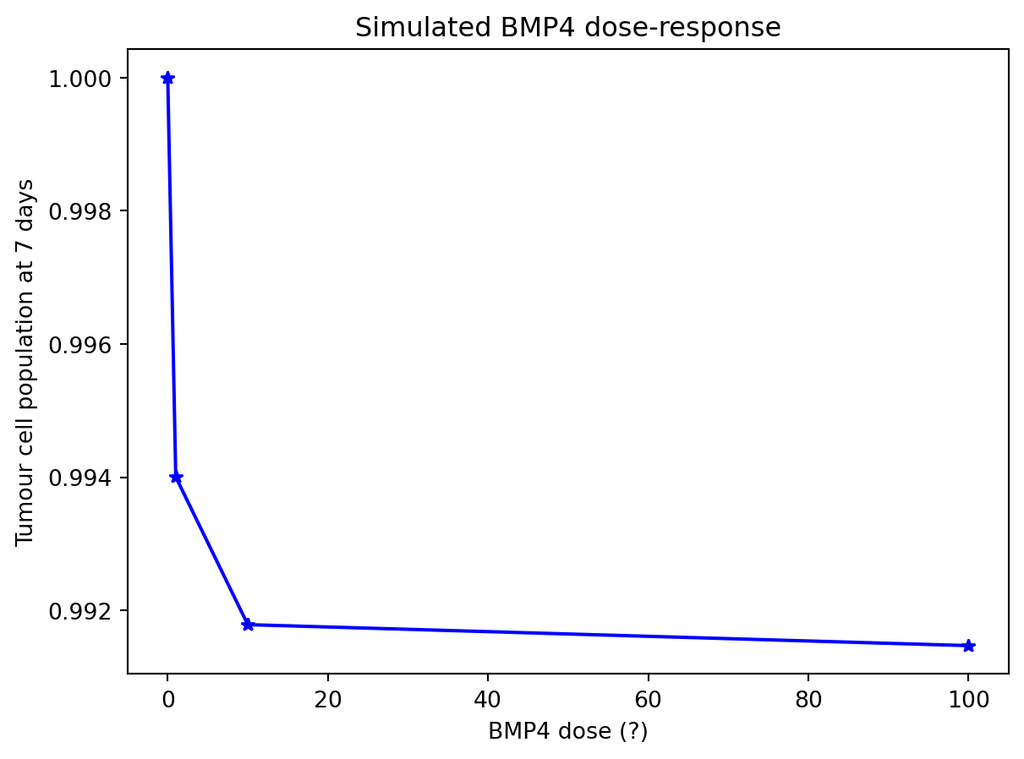

```python
plt.plot(BMP4_doses,N_save[:,-1]/N_save[0,-1],'b-*')
plt.xlabel("BMP4 dose (?)")
plt.ylabel("Tumour cell population at 7 days")
plt.title("Simulated BMP4 dose-response")
plt.show()
```

This data gives some idea of relative proliferaion rates. We have the known doubling time of GBM1a and QNS120. 54.71329 and 43.5243 hrs respectively.

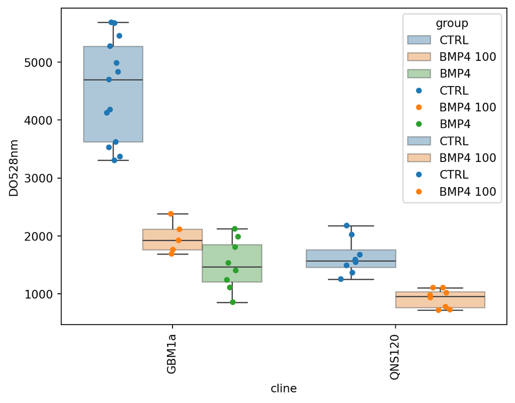

```python
GBM1a_pro_df = prolif_df2[prolif_df2["cline"] == "GBM1a"]
QNS120_pro_df = prolif_df2[prolif_df2["cline"] == "QNS120"]


plt.figure()
plt.xticks(rotation='vertical')
sns.boxplot(data=prolif_df2[(prolif_df2.cline=="GBM1a") & (prolif_df2.exclude!="yes")], x='cline', y='DO528nm', hue='group', boxprops={'alpha': 0.4})
sns.stripplot(data=prolif_df2[(prolif_df2.cline=="GBM1a") & (prolif_df2.exclude!="yes")], x='cline', y='DO528nm', hue='group', dodge=True)

sns.boxplot(data=prolif_df2[(prolif_df2.cline=="QNS120") & (prolif_df2.exclude!="yes")], x='cline', y='DO528nm', hue='group', boxprops={'alpha': 0.4})
sns.stripplot(data=prolif_df2[(prolif_df2.cline=="QNS120") & (prolif_df2.exclude!="yes")], x='cline', y='DO528nm', hue='group', dodge=True)
```